# 1 Background

As a statistical consultant working for a real estate investment firm, your task is to develop a model to predict the selling price of a given home in Ames, Iowa. Your employer hopes to use this information to help assess whether the asking price of a house is higher or lower than the true value of the house. If the home is undervalued, it may be a good investment for the firm.

# 2 Training Data and relevant packages

In order to better assess the quality of the model you will produce, the data have been randomly divided into three separate pieces: a training data set, a testing data set, and a validation data set. For now we will load the training data set, the others will be loaded and used later.

```r
load("ames_train.Rdata")
```

Use the code block below to load any necessary packages

```r
library(statsr)
library(dplyr)
library(BAS)
```

```r
library(corrplot)
library(GGally)
library(MASS)
library(ggplot2)
library(knitr)
```

## 2.1 Part 1 - Exploratory Data Analysis (EDA)

When you first get your data, it’s very tempting to immediately begin fitting models and assessing how they perform. However, before you begin modeling, it’s absolutely essential to explore the structure of the data and the relationships between the variables in the data set.

Do a detailed EDA of the ames_train data set, to learn about the structure of the data and the relationships between the variables in the data set (refer to Introduction to Probability and Data, Week 2, for a reminder about EDA if needed). Your EDA should involve creating and reviewing many plots/graphs and considering the patterns and relationships you see.

After you have explored completely, submit the three graphs/plots that you found most informative during your EDA process, and briefly explain what you learned from each (why you found each informative).

For the begining we have a look at at the data.

```r
head(ames_train)
```

```
## # A tibble: 6 x 81
##      PID  area  price MS.SubClass MS.Zoning Lot.Frontage Lot.Area Street Alley
##    <int> <int>  <int>       <int> <fct>            <int>    <int> <fct>  <fct>
## 1 9.09e8   856 126000          30 RL                  NA     7890 Pave   <NA>
## 2 9.05e8  1049 139500         120 RL                  42     4235 Pave   <NA>
## 3 9.11e8  1001 124900          30 C (all)             60     6060 Pave   <NA>
## 4 5.35e8  1039 114000          70 RL                  80     8146 Pave   <NA>
## 5 5.34e8  1665 227000          60 RL                  70     8400 Pave   <NA>
## 6 9.08e8  1922 198500          85 RL                  64     7301 Pave   <NA>
## # ... with 72 more variables: Lot.Shape <fct>, Land.Contour <fct>,
## #   Utilities <fct>, Lot.Config <fct>, Land.Slope <fct>, Neighborhood <fct>,
## #   Condition.1 <fct>, Condition.2 <fct>, Bldg.Type <fct>, House.Style <fct>,
## #   Overall.Qual <int>, Overall.Cond <int>, Year.Built <int>,
## #   Year.Remod.Add <int>, Roof.Style <fct>, Roof.Matl <fct>,
## #   Exterior.1st <fct>, Exterior.2nd <fct>, Mas.Vnr.Type <fct>,
## #   Mas.Vnr.Area <int>, Exter.Qual <fct>, Exter.Cond <fct>, Foundation <fct>,
## #   Bsmt.Qual <fct>, Bsmt.Cond <fct>, Bsmt.Exposure <fct>,
## #   BsmtFin.Type.1 <fct>, BsmtFin.SF.1 <int>, BsmtFin.Type.2 <fct>,
## #   BsmtFin.SF.2 <int>, Bsmt.Unf.SF <int>, Total.Bsmt.SF <int>, Heating <fct>,
## #   Heating.QC <fct>, Central.Air <fct>, Electrical <fct>, X1st.Flr.SF <int>,
## #   X2nd.Flr.SF <int>, Low.Qual.Fin.SF <int>, Bsmt.Full.Bath <int>,
## #   Bsmt.Half.Bath <int>, Full.Bath <int>, Half.Bath <int>,
## #   Bedroom.AbvGr <int>, Kitchen.AbvGr <int>, Kitchen.Qual <fct>,
## #   TotRms.AbvGrd <int>, Functional <fct>, Fireplaces <int>,
## #   Fireplace.Qu <fct>, Garage.Type <fct>, Garage.Yr.Blt <int>,
## #   Garage.Finish <fct>, Garage.Cars <int>, Garage.Area <int>,
## #   Garage.Qual <fct>, Garage.Cond <fct>, Paved.Drive <fct>,
## #   Wood.Deck.SF <int>, Open.Porch.SF <int>, Enclosed.Porch <int>,
## #   X3Ssn.Porch <int>, Screen.Porch <int>, Pool.Area <int>, Pool.QC <fct>,
## #   Fence <fct>, Misc.Feature <fct>, Misc.Val <int>, Mo.Sold <int>,
## #   Yr.Sold <int>, Sale.Type <fct>, Sale.Condition <fct>
```

Finding missing values:

```r
sapply(ames_train, function(x) sum(is.na(x)))
```

```
##             PID            area           price     MS.SubClass       MS.Zoning
##               0               0               0               0               0
##    Lot.Frontage        Lot.Area          Street           Alley       Lot.Shape
##             167               0               0             933               0
##    Land.Contour       Utilities      Lot.Config      Land.Slope    Neighborhood
##               0               0               0               0               0
##     Condition.1     Condition.2       Bldg.Type     House.Style    Overall.Qual
##               0               0               0               0               0
##    Overall.Cond      Year.Built  Year.Remod.Add      Roof.Style       Roof.Matl
##               0               0               0               0               0
##    Exterior.1st    Exterior.2nd    Mas.Vnr.Type    Mas.Vnr.Area      Exter.Qual
##               0               0               0               7               0
##      Exter.Cond      Foundation       Bsmt.Qual       Bsmt.Cond   Bsmt.Exposure
##               0               0              21              21              21
##  BsmtFin.Type.1    BsmtFin.SF.1  BsmtFin.Type.2    BsmtFin.SF.2     Bsmt.Unf.SF
##              21               1              21               1               1
##   Total.Bsmt.SF         Heating      Heating.QC     Central.Air      Electrical
##               1               0               0               0               0
##     X1st.Flr.SF     X2nd.Flr.SF Low.Qual.Fin.SF  Bsmt.Full.Bath  Bsmt.Half.Bath
##               0               0               0               1               1
##       Full.Bath       Half.Bath   Bedroom.AbvGr   Kitchen.AbvGr    Kitchen.Qual
##               0               0               0               0               0
##   TotRms.AbvGrd      Functional      Fireplaces    Fireplace.Qu     Garage.Type
##               0               0               0             491              46
##   Garage.Yr.Blt   Garage.Finish     Garage.Cars     Garage.Area     Garage.Qual
##              48              46               1               1              47
##     Garage.Cond     Paved.Drive    Wood.Deck.SF   Open.Porch.SF  Enclosed.Porch
##              47               0               0               0               0
##     X3Ssn.Porch    Screen.Porch       Pool.Area         Pool.QC           Fence
##               0               0               0             997             798
##    Misc.Feature        Misc.Val         Mo.Sold         Yr.Sold       Sale.Type
##             971               0               0               0               0
##  Sale.Condition
##               0
```

Have a look on chart:

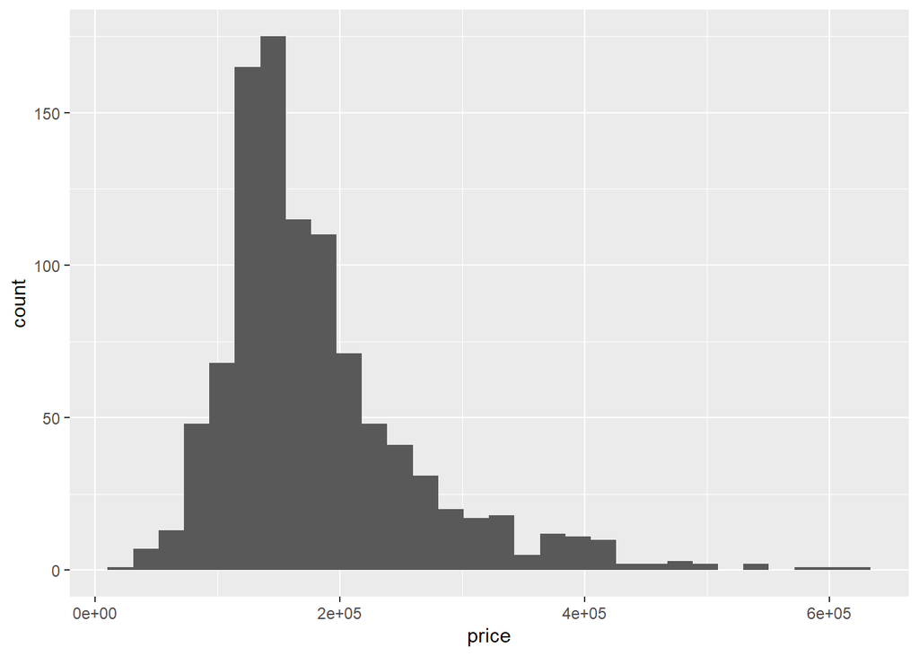

```r
ggplot(ames_train, aes(x=price))+
  geom_histogram()
```

Now i am going to analyze sales in the data set. We are going to find the correlation between variables to price which fit best.

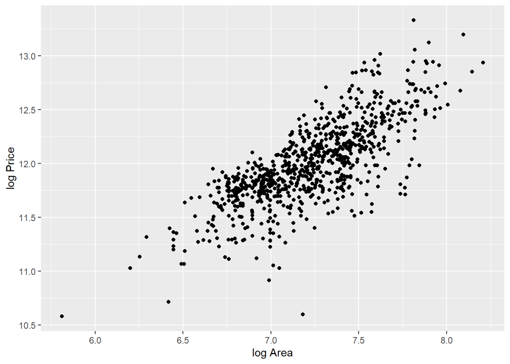

```r
ames_train$MS.SubClass <- as.factor(ames_train$MS.SubClass)
normal.sales <- ames_train%>%
  filter(Sale.Condition=='Normal')
ggplot(normal.sales, aes(x=log(area), y=log(price)))+geom_jitter()+xlab('log Area')+ylab('log Price')
```

Now, Ovaer Quality and price relation:

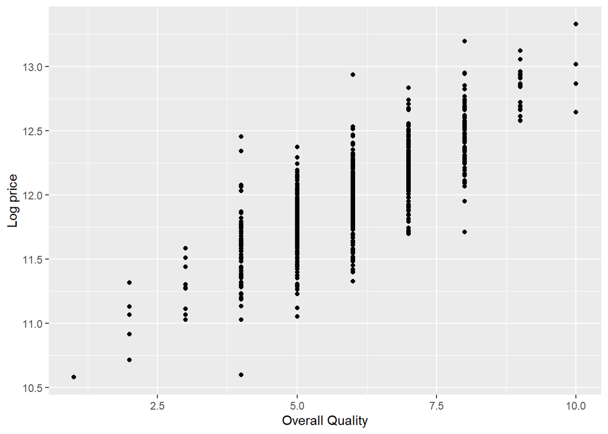

```r
ggplot(normal.sales, aes(x=Overall.Qual, y=log(price)))+geom_point()+xlab('Overall Quality')+ylab('Log price')
```

Now finding the effect of construction year to the price:

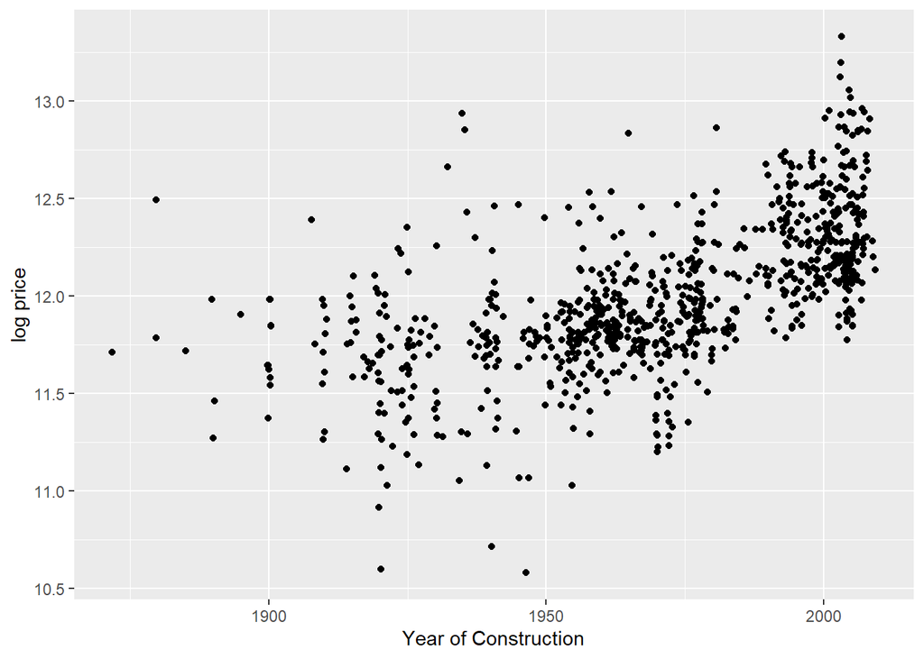

```r
ggplot(normal.sales, aes(x=Year.Built, y=log(price)))+geom_jitter()+xlab('Year of Construction')+ylab('log price')
```

## 2.2 Part 2 - Development and assessment of an initial model, following a semi-guided process of analysis

### 2.2.1 Section 2.1 An Initial Model

In building a model, it is often useful to start by creating a simple, intuitive initial model based on the results of the exploratory data analysis. (Note: The goal at this stage is **not** to identify the “best” possible model but rather to choose a reasonable and understandable starting point. Later you will expand and revise this model to create your final model.

Based on your EDA, select *at most* 10 predictor variables from “ames_train” and create a linear model for `price` (or a transformed version of price) using those variables. Provide the *R code* and the *summary output table* for your model, a *brief justification* for the variables you have chosen, and a *brief discussion* of the model results in context (focused on the variables that appear to be important predictors and how they relate to sales price).

Buildiing a model with the higher correlation variables to price. We get to know the adj r_sq value is 86.14% which means that there is a variation in the training data set are related to the variables in model.

```r
model_full <- lm(log(price) ~ log(area) + log(Lot.Area) + Year.Built + Overall.Qual + Bedroom.AbvGr + TotRms.AbvGrd + Full.Bath,normal.sales)
summary(model_full)
```

```
##
## Call:
## lm(formula = log(price) ~ log(area) + log(Lot.Area) + Year.Built +
##     Overall.Qual + Bedroom.AbvGr + TotRms.AbvGrd + Full.Bath,
##     data = normal.sales)
##
## Residuals:
##      Min       1Q   Median       3Q      Max
## -0.97210 -0.08370  0.00655  0.09320  0.58597
##
## Coefficients:
##                 Estimate Std. Error t value Pr(>|t|)
## (Intercept)   -0.7495250  0.4857374  -1.543   0.1232
## log(area)      0.4964457  0.0321243  15.454  < 2e-16 ***
## log(Lot.Area)  0.1589831  0.0101776  15.621  < 2e-16 ***
## Year.Built     0.0036502  0.0002236  16.325  < 2e-16 ***
## Overall.Qual   0.1149933  0.0057970  19.837  < 2e-16 ***
## Bedroom.AbvGr -0.0391574  0.0088802  -4.410 1.17e-05 ***
## TotRms.AbvGrd -0.0005214  0.0061426  -0.085   0.9324
## Full.Bath     -0.0340287  0.0135634  -2.509   0.0123 *
## ---
## Signif. codes:  0 '***' 0.001 '**' 0.01 '*' 0.05 '.' 0.1 ' ' 1
##
## Residual standard error: 0.1422 on 826 degrees of freedom
## Multiple R-squared:  0.8626, Adjusted R-squared:  0.8614
## F-statistic: 740.7 on 7 and 826 DF,  p-value: < 2.2e-16
```

### 2.2.2 Section 2.2 Model Selection

Now either using `BAS` another stepwise selection procedure choose the “best” model you can, using your initial model as your starting point. Try at least two different model selection methods and compare their results. Do they both arrive at the same model or do they disagree? What do you think this means?

To get to know which model fit best we are going to have different models.

```r
model_full_bas <- bas.lm(log(price)~ log(area)+log(Lot.Area)+Year.Built+Overall.Qual+ Bedroom.AbvGr+TotRms.AbvGrd+Full.Bath, normal.sales, prior='BIC', modelprior = uniform())
summary(model_full_bas)
```

```
##               P(B != 0 | Y)    model 1       model 2       model 3
## Intercept        1.00000000     1.0000     1.0000000  1.000000e+00
## log(area)        1.00000000     1.0000     1.0000000  1.000000e+00
## log(Lot.Area)    1.00000000     1.0000     1.0000000  1.000000e+00
## Year.Built       1.00000000     1.0000     1.0000000  1.000000e+00
## Overall.Qual     1.00000000     1.0000     1.0000000  1.000000e+00
## Bedroom.AbvGr    0.99982511     1.0000     1.0000000  1.000000e+00
## TotRms.AbvGrd    0.03429629     0.0000     0.0000000  1.000000e+00
## Full.Bath        0.45990901     0.0000     1.0000000  0.000000e+00
## BF                       NA     1.0000     0.8524512  3.609375e-02
## PostProbs                NA     0.5212     0.4443000  1.880000e-02
## R2                       NA     0.8615     0.8626000  8.615000e-01
## dim                      NA     6.0000     7.0000000  7.000000e+00
## logmarg                  NA -1197.2834 -1197.4430477 -1.200605e+03
##                     model 4       model 5
## Intercept      1.000000e+00  1.000000e+00
## log(area)      1.000000e+00  1.000000e+00
## log(Lot.Area)  1.000000e+00  1.000000e+00
## Year.Built     1.000000e+00  1.000000e+00
## Overall.Qual   1.000000e+00  1.000000e+00
## Bedroom.AbvGr  1.000000e+00  0.000000e+00
## TotRms.AbvGrd  1.000000e+00  0.000000e+00
## Full.Bath      1.000000e+00  1.000000e+00
## BF             2.962554e-02  2.091542e-04
## PostProbs      1.540000e-02  1.000000e-04
## R2             8.626000e-01  8.587000e-01
## dim            8.000000e+00  6.000000e+00
## logmarg       -1.200803e+03 -1.205756e+03
```

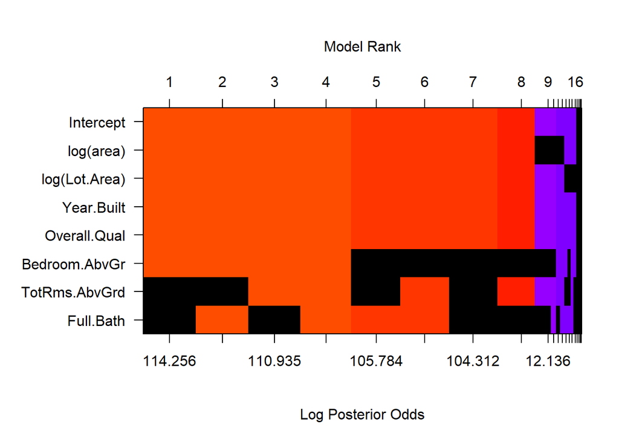

```r
image(model_full_bas, rotate = FALSE)
```

```r
stepAIC(k=log(nrow(normal.sales)),model_full)
```

```
## Start:  AIC=-3208.07
## log(price) ~ log(area) + log(Lot.Area) + Year.Built + Overall.Qual +
##     Bedroom.AbvGr + TotRms.AbvGrd + Full.Bath
##
##                 Df Sum of Sq    RSS     AIC
## - TotRms.AbvGrd  1    0.0001 16.695 -3214.8
## - Full.Bath      1    0.1272 16.822 -3208.5
## <none>                       16.695 -3208.1
## - Bedroom.AbvGr  1    0.3930 17.088 -3195.4
## - log(area)      1    4.8270 21.522 -3003.0
## - log(Lot.Area)  1    4.9319 21.627 -2998.9
## - Year.Built     1    5.3864 22.081 -2981.6
## - Overall.Qual   1    7.9532 24.648 -2889.9
##
## Step:  AIC=-3214.79
## log(price) ~ log(area) + log(Lot.Area) + Year.Built + Overall.Qual +
##     Bedroom.AbvGr + Full.Bath
##
##                 Df Sum of Sq    RSS     AIC
## - Full.Bath      1    0.1287 16.824 -3215.1
## <none>                       16.695 -3214.8
## - Bedroom.AbvGr  1    0.4741 17.169 -3198.2
## - log(Lot.Area)  1    5.0154 21.710 -3002.4
## - Year.Built     1    5.4832 22.178 -2984.7
## - log(area)      1    6.3878 23.083 -2951.3
## - Overall.Qual   1    7.9561 24.651 -2896.5
##
## Step:  AIC=-3215.11
## log(price) ~ log(area) + log(Lot.Area) + Year.Built + Overall.Qual +
##     Bedroom.AbvGr
##
##                 Df Sum of Sq    RSS     AIC
## <none>                       16.824 -3215.1
## - Bedroom.AbvGr  1    0.5455 17.369 -3195.2
## - log(Lot.Area)  1    5.1689 21.993 -2998.4
## - Year.Built     1    5.5914 22.415 -2982.5
## - log(area)      1    6.8081 23.632 -2938.4
## - Overall.Qual   1    7.9095 24.733 -2900.5
```

```
##
## Call:
## lm(formula = log(price) ~ log(area) + log(Lot.Area) + Year.Built +
##     Overall.Qual + Bedroom.AbvGr, data = normal.sales)
##
## Coefficients:
##   (Intercept)      log(area)  log(Lot.Area)     Year.Built   Overall.Qual
##     -0.213468       0.466309       0.160810       0.003458       0.114606
## Bedroom.AbvGr
##     -0.042002
```

Now BIC model:

```r
BIC(model_full)
```

```
## [1] -834.5579
```

Now removing variables:

```r
model_with_nobedrooms <- lm(log(price)~log(area) + log(Lot.Area) + Year.Built + Overall.Qual + TotRms.AbvGrd,normal.sales)
BIC(model_with_nobedrooms)
```

```
## [1] -820.4852
```

Model with no rooms:

```r
model_with_no_rooms <- lm(log(price)~log(area) + log(Lot.Area) + Year.Built + Overall.Qual + Bedroom.AbvGr,normal.sales)
BIC(model_with_no_rooms)
```

```
## [1] -841.5961
```

Final model:

```r
model_final <- lm(log(price)~log(area) + log(Lot.Area) + Year.Built + Overall.Qual + Bedroom.AbvGr,normal.sales)
summary(model_final)
```

```
##
## Call:
## lm(formula = log(price) ~ log(area) + log(Lot.Area) + Year.Built +
##     Overall.Qual + Bedroom.AbvGr, data = normal.sales)
##
## Residuals:
##      Min       1Q   Median       3Q      Max
## -0.96581 -0.08579  0.00802  0.09369  0.56239
##
## Coefficients:
##                 Estimate Std. Error t value Pr(>|t|)
## (Intercept)   -0.2134679  0.4363425  -0.489    0.625
## log(area)      0.4663086  0.0254746  18.305  < 2e-16 ***
## log(Lot.Area)  0.1608100  0.0100823  15.950  < 2e-16 ***
## Year.Built     0.0034578  0.0002084  16.589  < 2e-16 ***
## Overall.Qual   0.1146059  0.0058087  19.730  < 2e-16 ***
## Bedroom.AbvGr -0.0420016  0.0081060  -5.182 2.77e-07 ***
## ---
## Signif. codes:  0 '***' 0.001 '**' 0.01 '*' 0.05 '.' 0.1 ' ' 1
##
## Residual standard error: 0.1425 on 828 degrees of freedom
## Multiple R-squared:  0.8615, Adjusted R-squared:  0.8607
## F-statistic:  1030 on 5 and 828 DF,  p-value: < 2.2e-16
```

### 2.2.3 Section 2.3 Initial Model Residuals

One way to assess the performance of a model is to examine the model’s residuals. In the space below, create a residual plot for your preferred model from above and use it to assess whether your model appears to fit the data well. Comment on any interesting structure in the residual plot (trend, outliers, etc.) and briefly discuss potential implications it may have for your model and inference / prediction you might produce.

To have a look on residuals following plots are created.

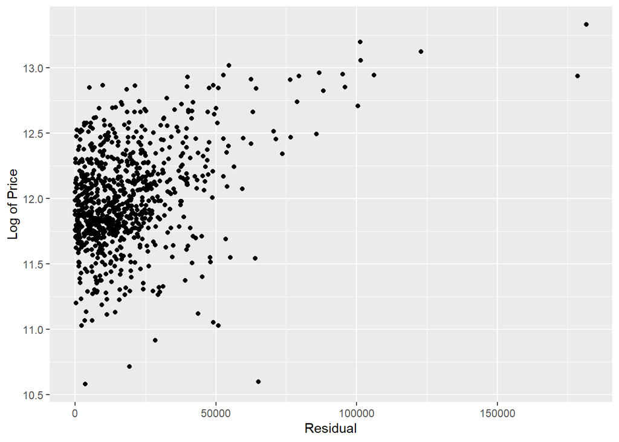

```r
normal.sales$predicted.price <- exp(predict(model_final))
normal.sales$residual <- sqrt((normal.sales$predicted.price - normal.sales$price)^2)
ggplot(normal.sales, aes(residual, log(price))) + geom_point() + ylab('Log of Price') + xlab('Residual')
```

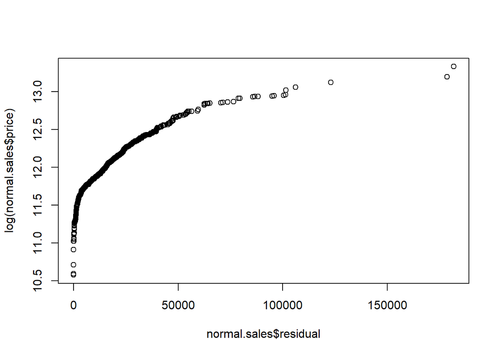

```r
qqplot(normal.sales$residual,log(normal.sales$price))
```

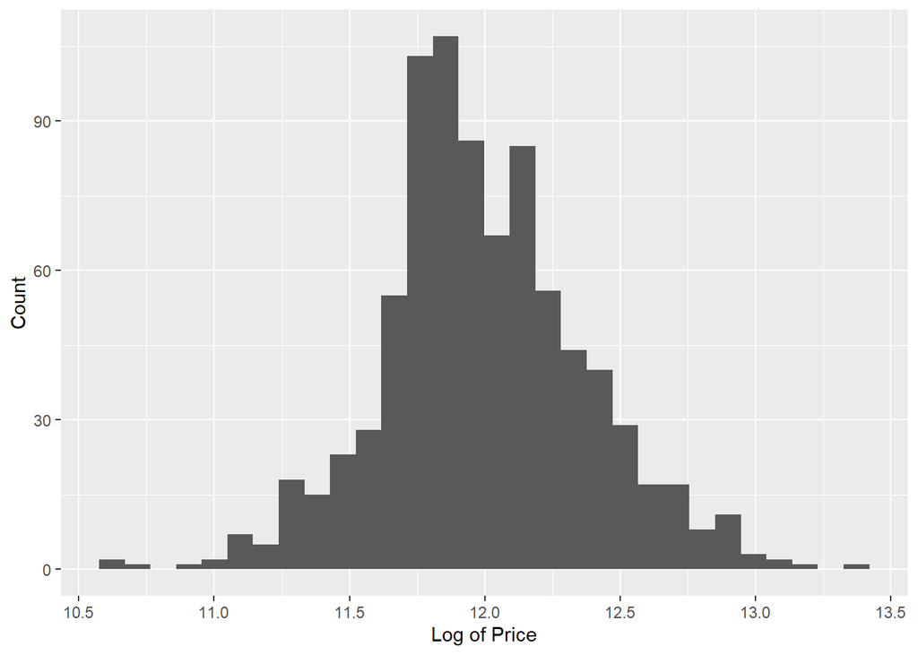

```r
ggplot(normal.sales, aes(log(price))) + geom_histogram() + xlab('Log of Price') + ylab('Count')
```

### 2.2.4 Section 2.4 Initial Model RMSE

You can calculate it directly based on the model output. Be specific about the units of your RMSE (depending on whether you transformed your response variable). The value you report will be more meaningful if it is in the original units (dollars).

As according to the above model predicting housing price is $18475.21 on average.

```r
mean(normal.sales$residual)
```

```
## [1] 18475.21
```

### 2.2.5 Section 2.5 Overfitting

The process of building a model generally involves starting with an initial model (as you have done above), identifying its shortcomings, and adapting the model accordingly. This process may be repeated several times until the model fits the data reasonably well. However, the model may do well on training data but perform poorly out-of-sample (meaning, on a dataset other than the original training data) because the model is overly-tuned to specifically fit the training data. This is called “overfitting.” To determine whether overfitting is occurring on a model, compare the performance of a model on both in-sample and out-of-sample data sets. To look at performance of your initial model on out-of-sample data, you will use the data set `ames_test`.

```r
load("ames_test.Rdata")
```

Use your model from above to generate predictions for the housing prices in the test data set. Are the predictions significantly more accurate (compared to the actual sales prices) for the training data than the test data? Why or why not? Briefly explain how you determined that (what steps or processes did you use)?

Started with an initial model, identified its shortcomings, and adopt the model accordingly. This process may be repeated several times until the model fits the data reasonably well. However, the model may do well on training data but perform poorly out-of-sample because the model is overly-tuned to specifically fit the training data. This is called “overfitting.” To determine whether overfitting is occurring on a model, compare the performance of a model on both in-sample and out-of-sample data sets.

```r
ames_test$MS.SubClass <- as.factor(ames_test$MS.SubClass)
normal.sales.test <- ames_test %>%
  filter(Sale.Condition == 'Normal')
normal.sales.test$predicted.price <- exp(predict(model_final,ames_test))
normal.sales.test$residual <- sqrt((normal.sales.test$predicted.price - normal.sales.test$price)^2)

mean(normal.sales.test$residual)
```

```
## [1] 19708.74
```

```r
predict.full.train <- exp(predict(model_final, normal.sales, interval = 'prediction'))
coverage.full.train <-
  mean(normal.sales$price > predict.full.train[,'lwr'] &
  normal.sales$price < predict.full.train[,'upr'])
coverage.full.train
```

```
## [1] 0.9496403
```

```r
predict.full.test <- exp(predict(model_final, normal.sales.test, interval = 'prediction'))
coverage.full.test <-
  mean(normal.sales.test$price > predict.full.test[,'lwr'] &
  normal.sales.test$price < predict.full.test[,'upr'])
coverage.full.test
```

```
## [1] 0.9522644
```

```r
model_final_aic <- stepAIC(model_final)
```

```
## Start:  AIC=-3243.47
## log(price) ~ log(area) + log(Lot.Area) + Year.Built + Overall.Qual +
##     Bedroom.AbvGr
##
##                 Df Sum of Sq    RSS     AIC
## <none>                       16.824 -3243.5
## - Bedroom.AbvGr  1    0.5455 17.369 -3218.9
## - log(Lot.Area)  1    5.1689 21.993 -3022.0
## - Year.Built     1    5.5914 22.415 -3006.2
## - log(area)      1    6.8081 23.632 -2962.1
## - Overall.Qual   1    7.9095 24.733 -2924.1
```

**Note to the learner:** If in real-life practice this out-of-sample analysis shows evidence that the training data fits your model a lot better than the test data, it is probably a good idea to go back and revise the model (usually by simplifying the model) to reduce this overfitting. For simplicity, we do not ask you to do this on the assignment, however.

## 2.3 Part 3 Development of a Final Model

Now that you have developed an initial model to use as a baseline, create a final model with *at most* 20 variables to predict housing prices in Ames, IA, selecting from the full array of variables in the dataset and using any of the tools that we introduced in this specialization.

Carefully document the process that you used to come up with your final model, so that you can answer the questions below.

### 2.3.1 Section 3.1 Final Model

Provide the summary table for your model.

In final model we are going to add initial variables and some more variables that can affect the prdiction of home price. We have a look at adj r_sqr value which is higher than initial model. AIC model used after it to find the best fit model. Finally, we will calculate RMSE for the mmodel verification.

```r
model <- lm(log(price)~ log(area)+log(Lot.Area)+Bedroom.AbvGr+TotRms.AbvGrd+Year.Built+Overall.Qual+Overall.Cond+Neighborhood+Bldg.Type+Full.Bath+Half.Bath+MS.SubClass+Yr.Sold, normal.sales)
summary(model)
```

```
##
## Call:
## lm(formula = log(price) ~ log(area) + log(Lot.Area) + Bedroom.AbvGr +
##     TotRms.AbvGrd + Year.Built + Overall.Qual + Overall.Cond +
##     Neighborhood + Bldg.Type + Full.Bath + Half.Bath + MS.SubClass +
##     Yr.Sold, data = normal.sales)
##
## Residuals:
##      Min       1Q   Median       3Q      Max
## -0.78450 -0.06279  0.00015  0.06851  0.42424
##
## Coefficients: (2 not defined because of singularities)
##                       Estimate Std. Error t value Pr(>|t|)
## (Intercept)         -6.9073021  6.3117905  -1.094 0.274139
## log(area)            0.6015625  0.0311567  19.308  < 2e-16 ***
## log(Lot.Area)        0.1188025  0.0134250   8.849  < 2e-16 ***
## Bedroom.AbvGr       -0.0217972  0.0081364  -2.679 0.007540 **
## TotRms.AbvGrd       -0.0048803  0.0054048  -0.903 0.366830
## Year.Built           0.0046096  0.0004081  11.294  < 2e-16 ***
## Overall.Qual         0.0705555  0.0055575  12.696  < 2e-16 ***
## Overall.Cond         0.0599602  0.0041127  14.579  < 2e-16 ***
## NeighborhoodBlueste  0.0743273  0.0850935   0.873 0.382671
## NeighborhoodBrDale  -0.0344205  0.0708487  -0.486 0.627223
## NeighborhoodBrkSide -0.0219920  0.0564955  -0.389 0.697183
## NeighborhoodClearCr -0.0069413  0.0624791  -0.111 0.911567
## NeighborhoodCollgCr -0.0865487  0.0503662  -1.718 0.086122 .
## NeighborhoodCrawfor  0.0457600  0.0560776   0.816 0.414742
## NeighborhoodEdwards -0.1406336  0.0526379  -2.672 0.007704 **
## NeighborhoodGilbert -0.1062086  0.0529110  -2.007 0.045061 *
## NeighborhoodGreens   0.1525416  0.0733294   2.080 0.037830 *
## NeighborhoodGrnHill  0.2899235  0.0917212   3.161 0.001633 **
## NeighborhoodIDOTRR  -0.1476809  0.0577670  -2.556 0.010761 *
## NeighborhoodMeadowV -0.0905626  0.0614054  -1.475 0.140661
## NeighborhoodMitchel -0.0426141  0.0522561  -0.815 0.415043
## NeighborhoodNAmes   -0.0640591  0.0519375  -1.233 0.217802
## NeighborhoodNoRidge  0.0408904  0.0533501   0.766 0.443638
## NeighborhoodNPkVill  0.0405383  0.0752373   0.539 0.590175
## NeighborhoodNridgHt  0.0947826  0.0498991   1.899 0.057869 .
## NeighborhoodNWAmes  -0.0988201  0.0528264  -1.871 0.061766 .
## NeighborhoodOldTown -0.1095764  0.0559362  -1.959 0.050474 .
```

[output cut: 19 more lines]

```
## MS.SubClass75       -0.0057056  0.0504726  -0.113 0.910025
## MS.SubClass80       -0.0412968  0.0205536  -2.009 0.044857 *
## MS.SubClass85        0.0584129  0.0268162   2.178 0.029684 *
## MS.SubClass90               NA         NA      NA       NA
## MS.SubClass120      -0.0683367  0.0562922  -1.214 0.225128
## MS.SubClass160      -0.1994896  0.0546516  -3.650 0.000279 ***
## MS.SubClass180              NA         NA      NA       NA
## MS.SubClass190      -0.0676706  0.0860832  -0.786 0.432043
## Yr.Sold              0.0019048  0.0030981   0.615 0.538858
## ---
## Signif. codes:  0 '***' 0.001 '**' 0.01 '*' 0.05 '.' 0.1 ' ' 1
##
## Residual standard error: 0.1124 on 781 degrees of freedom
## Multiple R-squared:  0.9188, Adjusted R-squared:  0.9134
## F-statistic: 169.9 on 52 and 781 DF,  p-value: < 2.2e-16
```

Now AIC:

```r
model.aic <- stepAIC(model)
```

```
## Start:  AIC=-3594.66
## log(price) ~ log(area) + log(Lot.Area) + Bedroom.AbvGr + TotRms.AbvGrd +
##     Year.Built + Overall.Qual + Overall.Cond + Neighborhood +
##     Bldg.Type + Full.Bath + Half.Bath + MS.SubClass + Yr.Sold
##
##                 Df Sum of Sq     RSS     AIC
## - Bldg.Type      2    0.0206  9.8856 -3596.9
## - Full.Bath      1    0.0001  9.8650 -3596.7
## - Yr.Sold        1    0.0048  9.8697 -3596.3
## - TotRms.AbvGrd  1    0.0103  9.8752 -3595.8
## - Half.Bath      1    0.0166  9.8815 -3595.3
## <none>                        9.8649 -3594.7
## - Bedroom.AbvGr  1    0.0907  9.9556 -3589.0
## - MS.SubClass   12    0.9476 10.8125 -3542.2
## - log(Lot.Area)  1    0.9892 10.8541 -3517.0
## - Year.Built     1    1.6112 11.4762 -3470.5
## - Neighborhood  26    2.3673 12.2323 -3467.3
## - Overall.Qual   1    2.0358 11.9008 -3440.2
## - Overall.Cond   1    2.6848 12.5497 -3395.9
## - log(area)      1    4.7087 14.5737 -3271.2
##
## Step:  AIC=-3596.92
## log(price) ~ log(area) + log(Lot.Area) + Bedroom.AbvGr + TotRms.AbvGrd +
##     Year.Built + Overall.Qual + Overall.Cond + Neighborhood +
##     Full.Bath + Half.Bath + MS.SubClass + Yr.Sold
##
##                 Df Sum of Sq     RSS     AIC
## - Full.Bath      1    0.0000  9.8856 -3598.9
## - Yr.Sold        1    0.0050  9.8906 -3598.5
## - TotRms.AbvGrd  1    0.0129  9.8985 -3597.8
## - Half.Bath      1    0.0158  9.9014 -3597.6
## <none>                        9.8856 -3596.9
## - Bedroom.AbvGr  1    0.0836  9.9691 -3591.9
## - MS.SubClass   14    1.2414 11.1270 -3526.3
## - log(Lot.Area)  1    1.0489 10.9344 -3514.8
## - Year.Built     1    1.6103 11.4959 -3473.1
## - Neighborhood  26    2.3517 12.2373 -3470.9
## - Overall.Qual   1    2.0596 11.9451 -3441.1
## - Overall.Cond   1    2.6719 12.5575 -3399.4
## - log(area)      1    4.7150 14.6006 -3273.7
```

[output cut: 54 more lines]

```
##
## Step:  AIC=-3601.51
## log(price) ~ log(area) + log(Lot.Area) + Bedroom.AbvGr + Year.Built +
##     Overall.Qual + Overall.Cond + Neighborhood + MS.SubClass
##
##                 Df Sum of Sq     RSS     AIC
## <none>                        9.9261 -3601.5
## - Bedroom.AbvGr  1    0.1276 10.0537 -3592.9
## - MS.SubClass   14    1.3235 11.2496 -3525.1
## - log(Lot.Area)  1    1.0289 10.9550 -3521.3
## - Neighborhood  26    2.3501 12.2762 -3476.3
## - Year.Built     1    1.7126 11.6387 -3470.8
## - Overall.Qual   1    2.0662 11.9922 -3445.8
## - Overall.Cond   1    2.6651 12.5911 -3405.2
## - log(area)      1    6.9834 16.9095 -3159.2
```

Have a look on summary:

```r
summary(model.aic)
```

```
##
## Call:
## lm(formula = log(price) ~ log(area) + log(Lot.Area) + Bedroom.AbvGr +
##     Year.Built + Overall.Qual + Overall.Cond + Neighborhood +
##     MS.SubClass, data = normal.sales)
##
## Residuals:
##      Min       1Q   Median       3Q      Max
## -0.78675 -0.06314  0.00075  0.06941  0.43726
##
## Coefficients:
##                       Estimate Std. Error t value Pr(>|t|)
## (Intercept)         -3.1375233  0.8267534  -3.795 0.000159 ***
## log(area)            0.5911718  0.0251235  23.531  < 2e-16 ***
## log(Lot.Area)        0.1194204  0.0132217   9.032  < 2e-16 ***
## Bedroom.AbvGr       -0.0236581  0.0074376  -3.181 0.001526 **
## Year.Built           0.0046583  0.0003998  11.653  < 2e-16 ***
## Overall.Qual         0.0709356  0.0055422  12.799  < 2e-16 ***
## Overall.Cond         0.0596672  0.0041047  14.536  < 2e-16 ***
## NeighborhoodBlueste  0.0643777  0.0842610   0.764 0.445080
## NeighborhoodBrDale  -0.0440359  0.0690140  -0.638 0.523612
## NeighborhoodBrkSide -0.0172242  0.0560540  -0.307 0.758712
## NeighborhoodClearCr -0.0029636  0.0618828  -0.048 0.961815
## NeighborhoodCollgCr -0.0813280  0.0496626  -1.638 0.101903
## NeighborhoodCrawfor  0.0529518  0.0555132   0.954 0.340448
## NeighborhoodEdwards -0.1325587  0.0518811  -2.555 0.010804 *
## NeighborhoodGilbert -0.0975341  0.0520339  -1.874 0.061241 .
## NeighborhoodGreens   0.1527865  0.0719680   2.123 0.034067 *
## NeighborhoodGrnHill  0.2993445  0.0911573   3.284 0.001069 **
## NeighborhoodIDOTRR  -0.1416690  0.0572295  -2.475 0.013516 *
## NeighborhoodMeadowV -0.0862596  0.0609139  -1.416 0.157144
## NeighborhoodMitchel -0.0364575  0.0513950  -0.709 0.478311
## NeighborhoodNAmes   -0.0559632  0.0509639  -1.098 0.272498
## NeighborhoodNoRidge  0.0458024  0.0526747   0.870 0.384821
## NeighborhoodNPkVill  0.0330330  0.0729492   0.453 0.650802
## NeighborhoodNridgHt  0.0921344  0.0493089   1.869 0.062062 .
## NeighborhoodNWAmes  -0.0927458  0.0522212  -1.776 0.076116 .
## NeighborhoodOldTown -0.1022366  0.0554085  -1.845 0.065392 .
## NeighborhoodSawyer  -0.0715378  0.0521992  -1.370 0.170929
## NeighborhoodSawyerW -0.1251075  0.0508366  -2.461 0.014070 *
```

[output cut: 10 more lines]

```
## MS.SubClass70       -0.0596644  0.0309842  -1.926 0.054509 .
## MS.SubClass75       -0.0054570  0.0500369  -0.109 0.913183
## MS.SubClass80       -0.0409971  0.0205271  -1.997 0.046146 *
## MS.SubClass85        0.0556222  0.0267193   2.082 0.037690 *
## MS.SubClass90       -0.1427986  0.0247676  -5.766 1.17e-08 ***
## MS.SubClass120      -0.0413636  0.0241105  -1.716 0.086633 .
## MS.SubClass160      -0.1743446  0.0327811  -5.318 1.36e-07 ***
## MS.SubClass180       0.0178590  0.0564662   0.316 0.751875
## MS.SubClass190      -0.0195612  0.0331925  -0.589 0.555812
## ---
## Signif. codes:  0 '***' 0.001 '**' 0.01 '*' 0.05 '.' 0.1 ' ' 1
##
## Residual standard error: 0.1123 on 787 degrees of freedom
## Multiple R-squared:  0.9183, Adjusted R-squared:  0.9135
## F-statistic: 192.3 on 46 and 787 DF,  p-value: < 2.2e-16
```

Now prediction the price:

```r
normal.sales$final.price.prediction <- exp(predict(model.aic))
normal.sales$final.residuals <- sqrt((normal.sales$final.price.prediction - normal.sales$price)^2)
final.rmse.train <- mean(normal.sales$final.residuals)
final.rmse.train
```

```
## [1] 14253.23
```

```r
normal.sales.test$final.price.prediction <- exp(predict(model_final_aic,normal.sales.test))
normal.sales.test$final.residuals <- sqrt((normal.sales.test$final.price.prediction - normal.sales.test$price)^2)
final.rmse.test <- mean(normal.sales.test$final.residuals)
final.rmse.test
```

```
## [1] 19708.74
```

```r
predict.full.aic.train <- exp(predict(model.aic, normal.sales, interval = 'prediction'))
coverage.full.aic.train <-
  mean(normal.sales$price > predict.full.aic.train[,'lwr'] &
  normal.sales$price < predict.full.aic.train[,'upr'])
coverage.full.aic.train
```

```
## [1] 0.9556355
```

```r
predict.full.aic.test <- exp(predict(model_final_aic, normal.sales.test, interval = 'prediction'))
coverage.full.aic.test <-
  mean(normal.sales.test$price > predict.full.aic.test[,'lwr'] &
  normal.sales.test$price < predict.full.aic.test[,'upr'])
coverage.full.aic.test
```

```
## [1] 0.9522644
```

### 2.3.2 Section 3.2 Transformation

Did you decide to transform any variables? Why or why not? Explain in a few sentences.

Varibles which transformed are price, Lot.Area, Area and MS.Subclass into facrtor. To obtain better result.

### 2.3.3 Section 3.3 Variable Interaction

Did you decide to include any variable interactions? Why or why not? Explain in a few sentences.

Varibles has no direct affect to the price variable it is clear in EDA. To obtain higher adj r_sqr value we experiment the interaction and combination of different variables.

### 2.3.4 Section 3.4 Variable Selection

What method did you use to select the variables you included? Why did you select the method you used? Explain in a few sentences.

MASS package provide AIC method to find the best fit model by adding or removing the variables to obtaib the lowest AIC value. I think AIC model would effictively be best to improve the varible combiantion in the model.

### 2.3.5 Section 3.5 Model Testing

How did testing the model on out-of-sample data affect whether or how you changed your model? Explain in a few sentences.

## 2.4 Part 4 Final Model Assessment

### 2.4.1 Section 4.1 Final Model Residual

For your final model, create and briefly interpret an informative plot of the residuals.

Have a look on the following plots:

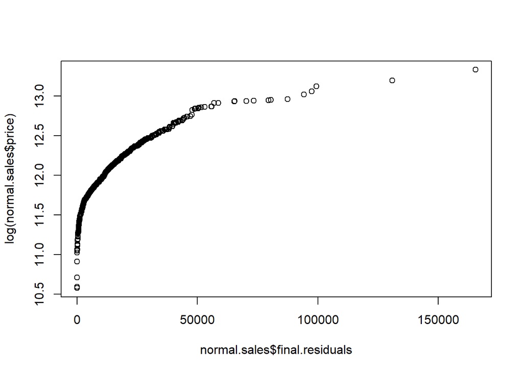

```r
qqplot(normal.sales$final.residuals, log(normal.sales$price))
```

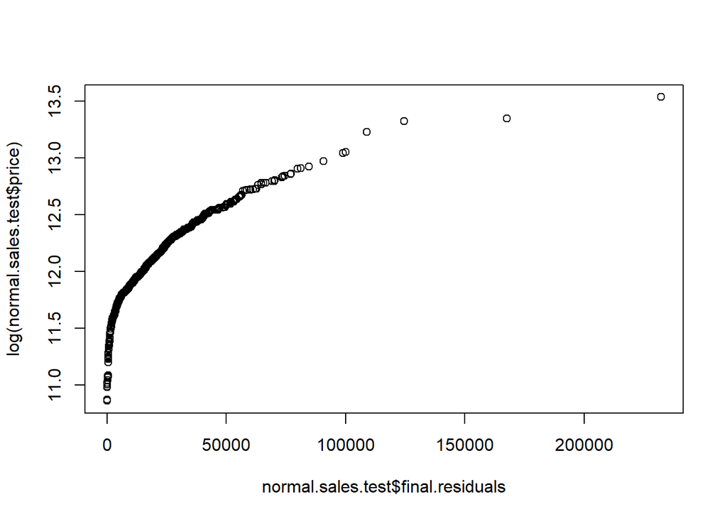

```r
qqplot(normal.sales.test$final.residuals, log(normal.sales.test$price))
```

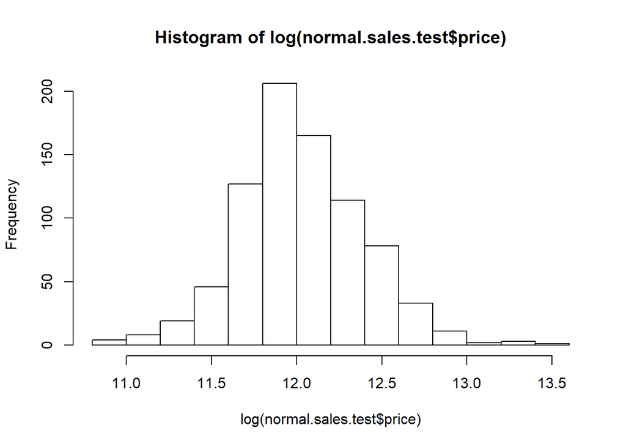

```r
hist(log(normal.sales.test$price))
```

Above plot shows that model’s accuecy decrease as the price increases. Log price is in the range of 11.5 to 12.5. There is a chance that if price infalted, it will not affect the other aspects of the home. Model works well with both data sets either of training and test with numbers of observations. * * *

### 2.4.2 Section 4.2 Final Model RMSE

For your final model, calculate and briefly comment on the RMSE.

### 2.4.3 Section 4.3 Final Model Evaluation

What are some strengths and weaknesses of your model?

As the price increases the accuracy descreases, model becomes less accurate. Model will predict less price for the home than the actual price. Model predict accrate home price for the mojority and it consist of no. of variables that are part of homes. Model is simple and can be applied to the no. of homes in the data set.

### 2.4.4 Section 4.4 Final Model Validation

Testing your final model on a separate, validation data set is a great way to determine how your model will perform in real-life practice.

You will use the “ames_validation” dataset to do some additional assessment of your final model. Discuss your findings, be sure to mention: * What is the RMSE of your final model when applied to the validation data?  
* How does this value compare to that of the training data and/or testing data? * What percentage of the 95% predictive confidence (or credible) intervals contain the true price of the house in the validation data set?  
* From this result, does your final model properly reflect uncertainty?

```r
load("ames_validation.Rdata")
```

```r
ames_validation$MS.SubClass <- factor(ames_validation$MS.SubClass)
normal.sales.validation <- ames_validation%>%
  filter(Sale.Condition=='Normal')
```

```r
normal.sales.validation$fianl.price.prediction <- exp(predict(model_final_aic,normal.sales.validation))
normal.sales.validation$fianl.residulas <- sqrt((normal.sales.validation$fianl.price.prediction-normal.sales.validation$price)^2)
final.rmse.validation<-mean(normal.sales.validation$fianl.residulas)
final.rmse.validation
```

```
## [1] 17548.58
```

```r
predict.full.aic.validation <- exp(predict(model_final_aic, normal.sales.validation, interval = 'prediction'))
coverage.full.aic.validation <-
  mean(normal.sales.validation$price > predict.full.aic.validation[,'lwr'] &
  normal.sales.validation$price < predict.full.aic.validation[,'upr'])
coverage.full.aic.validation
```

```
## [1] 0.9567497
```

## 2.5 Part 5 Conclusion

Provide a brief summary of your results, and a brief discussion of what you have learned about the data and your model.

Taking start from the EDA, finding correlation between variables, find whcih variable will affect the model to predict home’s price. Building different model and finally find the best fit model. Model predict price for home prediction very well. Throughout this project I have learnes a lot of techniques to obtain best result.